# Reproducible Research Project 1

Alena Stern

April 29, 2017

```r
knitr::opts_chunk$set(echo = TRUE)
```

## 1. Loading and Preprocessing the data

```r
setwd("~/Performance Review/JHU Data Science/Assignments/Reproducible Research")
fileURL <- "https://d396qusza40orc.cloudfront.net/repdata%2Fdata%2Factivity.zip"
download.file(fileURL, destfile = "./datazip.zip")
unzip("./datazip.zip", exdir = "./datazip")
data <- read.csv("./datazip/activity.csv", header = TRUE, sep= ",", fill = TRUE)
data$steps <- as.numeric(data$steps)
data$date <- as.Date(data$date)
data$interval <- as.numeric(data$interval)
```

Calculate total number of steps per day

```r
StepsPerDay <- aggregate(steps ~ date, data, FUN = sum)
```

Plot histogram of total number of steps per day

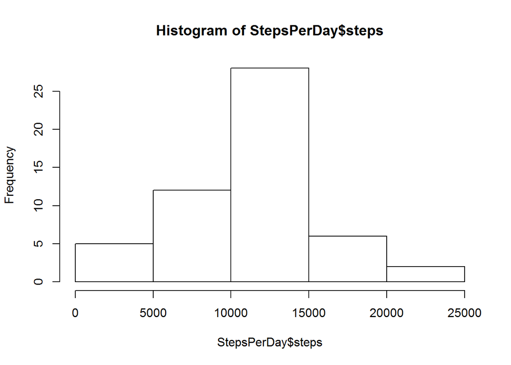

```r
hist(StepsPerDay$steps)
```

Calculate mean and median values of total number of steps per day

```r
meanStep <- mean(StepsPerDay$steps)
medianStep <- median(StepsPerDay$steps)
meanStep <- as.numeric(meanStep)
medianStep <- as.numeric(medianStep)
```

## 3. What is the average daily activity pattern?

Calculate the average number of steps per five minute interval

```r
ActivityPattern <- aggregate(steps ~ interval, data, FUN = mean)
```

Plot the average number of steps per five minute interval

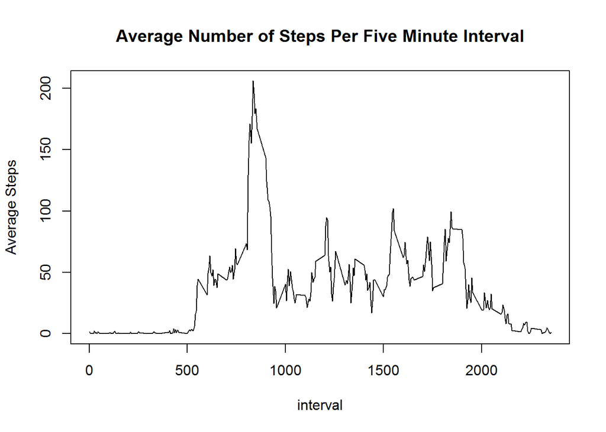

```r
plot(ActivityPattern$interval, ActivityPattern$steps, type = "l", main = "Average Number of Steps Per Five Minute Interval", xlab = "interval", ylab= "Average Steps")
```

Identify 5 minute interval with maximum average number of steps

```r
library(data.table)
DT <- as.data.table(ActivityPattern)
maxInt <- DT[,.SD[which.max(steps)]]
maxInt <- as.data.table(maxInt)
maxinterval <- maxInt$interval[1]
maxsteps <- maxInt$steps[1]
```

The interval with the highest average number of steps is interval 835 at 206.1698113 steps.

## 4. Imputing missing values

Calculate number of rows with NAs

```r
missing <-data[rowSums(is.na(data)) > 0,]
missingrows <- nrow(missing)
```

The dataset has 2304 rows with missing values

Imputing missing values based upon the average number of steps in the interval with the missing value.

```r
dataImpute <- data
setDT(dataImpute)[ActivityPattern, stepsi := i.steps, on='interval'][is.na(steps), steps := stepsi][,stepsi:= NULL][]
```

```
##            steps       date interval
##     1: 1.7169811 2012-10-01        0
##     2: 0.3396226 2012-10-01        5
##     3: 0.1320755 2012-10-01       10
##     4: 0.1509434 2012-10-01       15
##     5: 0.0754717 2012-10-01       20
##    ---
## 17564: 4.6981132 2012-11-30     2335
## 17565: 3.3018868 2012-11-30     2340
## 17566: 0.6415094 2012-11-30     2345
## 17567: 0.2264151 2012-11-30     2350
## 17568: 1.0754717 2012-11-30     2355
```

Calculate total number of steps per day for imputed dataset

```r
StepsPerDayImp <- aggregate(steps ~ date, dataImpute, FUN = sum)
```

Plot histogram of total number of steps per day for imputed dataset

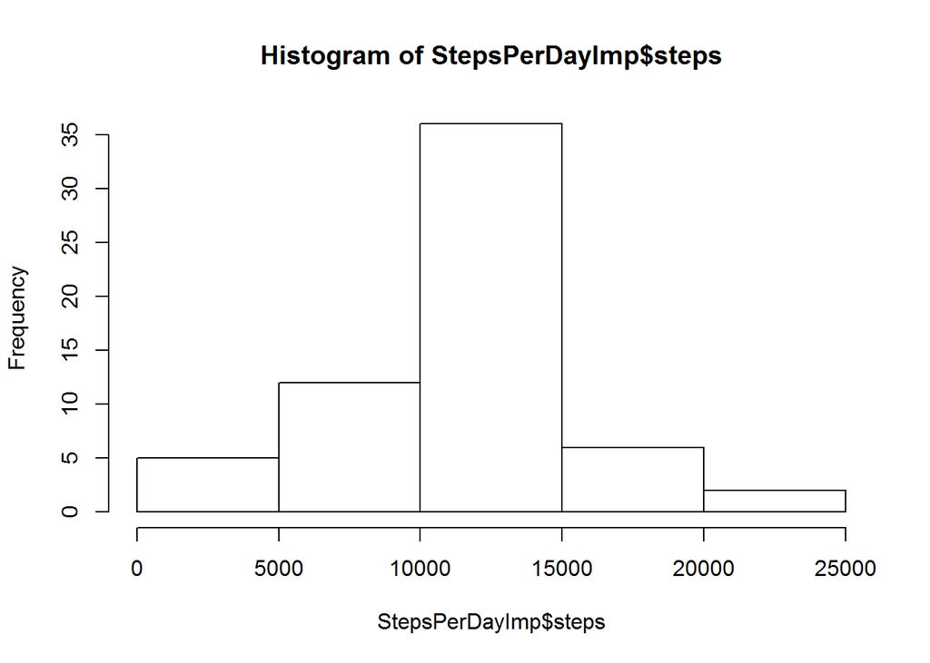

```r
hist(StepsPerDayImp$steps)
```

Calculate mean and median values of total number of steps per day for imputed dataset

```r
meanImp <- mean(StepsPerDayImp$steps)
medianImp <- median(StepsPerDayImp$steps)

DiffMean <- meanStep - meanImp
DiffMedian <- medianStep - medianImp
```

## 5. Are there differences in activity patterns between weekdays and weekends?

Creating factor variable to indicate whether a given date is a weekday or weekend.

```r
data[ ,"Weekday"] <-NA
weekdaynames <- c("Monday", "Tuesday", "Wednesday", "Thursday", "Friday")

data$Weekday <- ifelse(weekdays(data$date) %in% weekdaynames, 1, 2)

data$Weekday <- factor(data$Weekday, levels = c(1,2), labels = c("Weekday", "Weekend"))
```

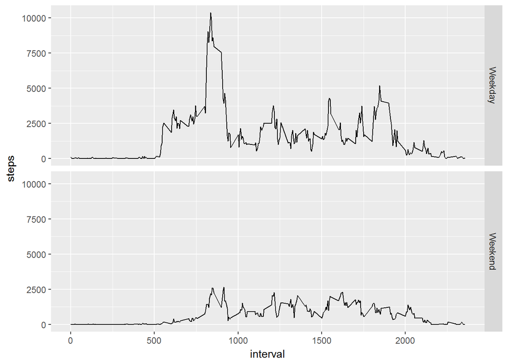

```r
weekData <- aggregate(steps ~ Weekday+interval, data=data, sum)
library(ggplot2)
wp <- ggplot(weekData, aes(x= interval, y= steps)) + geom_line()
wp + facet_grid(Weekday ~ .)
```